# Descriptive statistics

### Visual: histogram

**base**

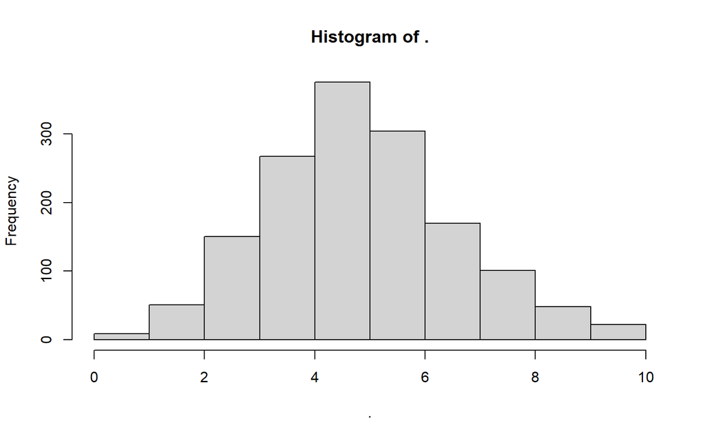

```r
df$Skepsis %>% hist
```

We can make it relative using a simple additional argument.

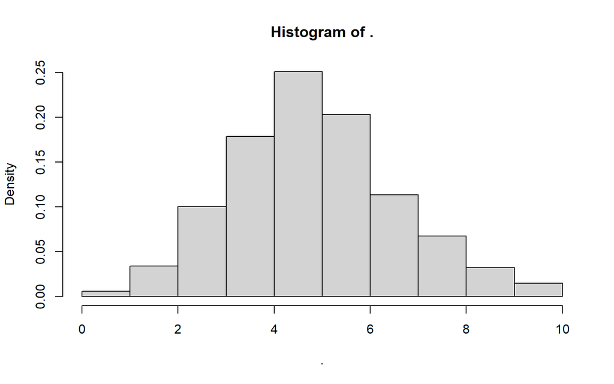

```r
df$Skepsis %>% hist(., probability = T)
```

**ggplot2** Histograms are easily implemented in ggplot too.

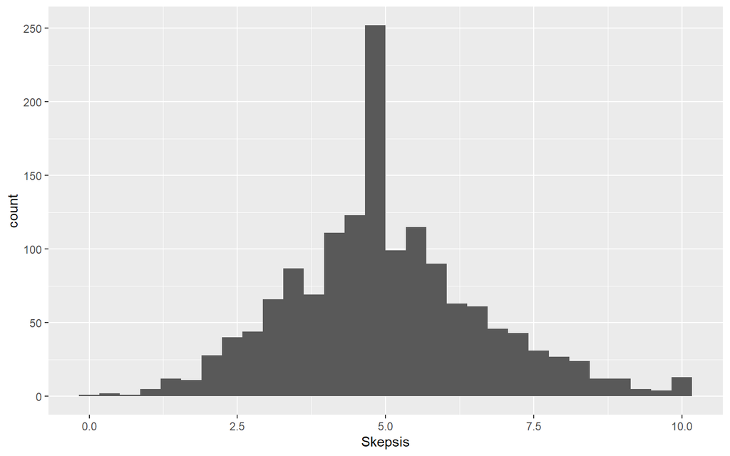

```r
df %>%
  ggplot +
  geom_histogram(aes(Skepsis))
```

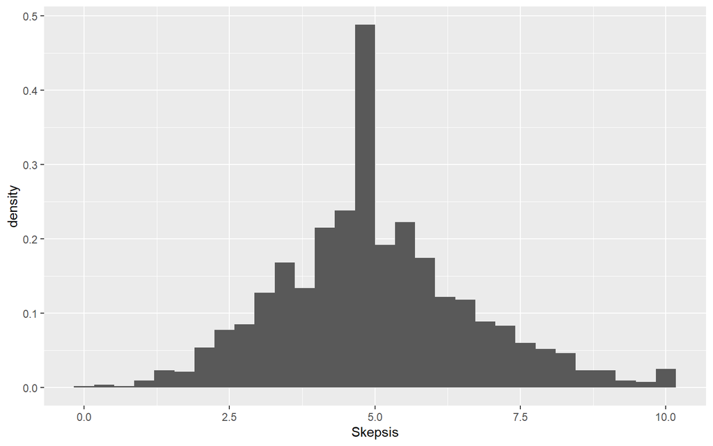

```r
df %>%
  ggplot(aes(x = Skepsis)) +
  geom_histogram(aes(y = after_stat(density)))
```

## Categorical variables

We can explore categorical variables primarily by their frequency distribution. That is, we count the number of observations we have in each category. This makes the basis both for the numeric summary (a frequency table) and the visual inspection (a barplot).

#### Numeric summary: frequency table

Here, we are looking at what our respondents voted last election.

We can make a simple frequency table in base using the `table()` function.

```r
df$Parti %>%
  table
```

```
## .
##                       Andet            Dansk Folkeparti
##                          17                         143
## Det Konservative Folkeparti        Det Radikale Venstre
##                          65                         134
##                Enhedslisten         Kristendemokraterne
##                          77                           8
##            Liberal Alliance          Socialdemokraterne
##                          48                         268
##     Socialistisk Folkeparti                     Venstre
##                         108                         311
```

We can also do this using tidyverse, by first grouping the data by party with `group_by()`, then count the number of occurences/observations within each group using `n()`.

```r
df %>%
  group_by(Parti) %>%
  reframe(n = n())
```

| Parti | n |
| --- | --- |
| Andet | 17 |
| Dansk Folkeparti | 143 |
| Det Konservative Folkeparti | 65 |
| Det Radikale Venstre | 134 |
| Enhedslisten | 77 |
| Kristendemokraterne | 8 |
| Liberal Alliance | 48 |
| Socialdemokraterne | 268 |
| Socialistisk Folkeparti | 108 |
| Venstre | 311 |

[output cut: 1 more lines]

### Visual: barplot

#### base

In base, we need to make the frequency table first, then plot it using the appropriate function.

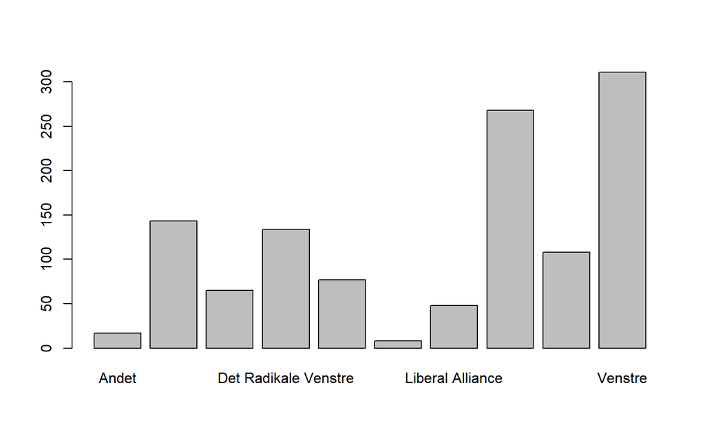

```r
df$Parti %>%
  table %>%
  barplot()
```

Usually, it is much more intuitive to check the relative distribution than the absolute. The function `prop.table()` does exactly that for us.

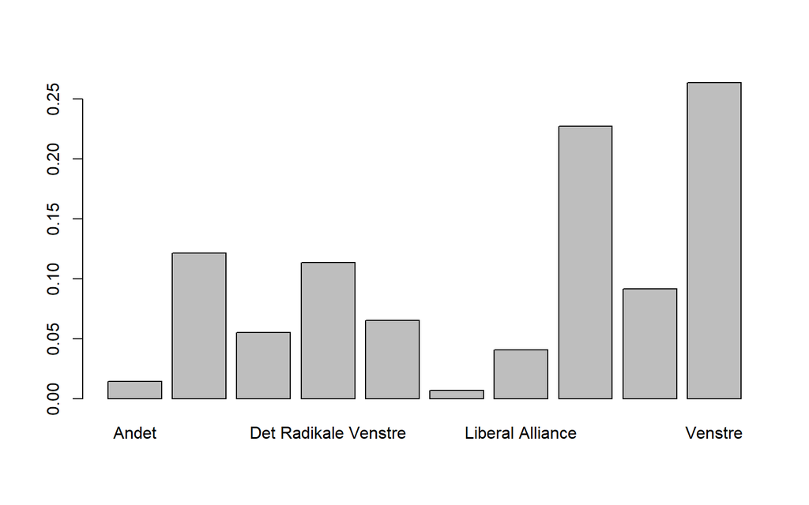

```r
df$Parti %>%
  #Frequency table
  table %>%
  #Relative distribution
  prop.table %>%
  #Barplot
  barplot()
```

#### ggplot2

In ggplot2, R does the frequency plot for us.

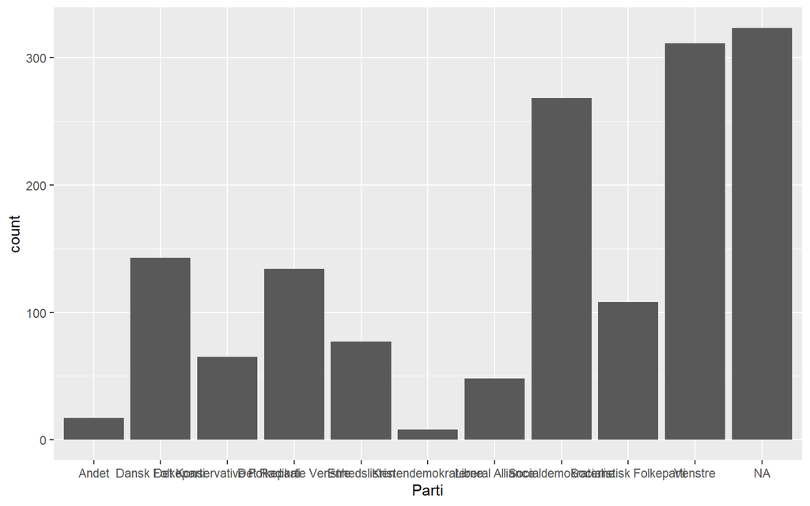

```r
df %>%
  ggplot +
  geom_bar(aes(Parti))
```

Do you notice the difference? The base function removes all “NA” (people who did not answer the question). In ggplot2, we’d have to remove them manually.

We can do that using tidyverse filtering!

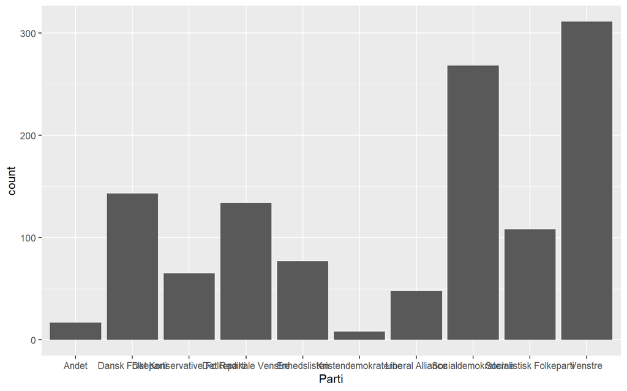

```r
df %>%
  #Filter out missing observations before plotting
  filter(!is.na(Parti)) %>%
  ggplot() +
  #Barplot
  geom_bar(aes(x = Parti))
```

> You can find more about data exploration in [this](https://ajsmit.github.io/Basic_stats/graphical-data-displays.html) tutorial, for example.

## Your turn!

1. Describe the distribution of education among respondents (`Uddannelse`). What do you see?
2. Replicate my barplot of the respondent’s party choice using ggplot2. Change the direction of the bars by swapping the x- and y-axes in the `aes()` specification.
3. Can you describe the distribution of respondents that have a weak link to the labor market (`Prekaritet`)?
4. Store the plot in an R object.

# Bivariate statistics

After exploring the variables separately, we usually check out their bivariate relationship. Once again, the choice of statistics depends on the measurement level.

## Two numeric variables

### Numeric summary: correlation

When we have two numeric variables, we can calculate their correlation using Pearsons R ($r$).

```r
cor(df$Indtaegt, df$Skepsis,
    use = "pairwise.complete.obs")
```

```
## [1] -0.1526337
```

The negative correlation is apparent, but what does it mean? Can we put it into plain English?

```r
cor(df$Indtaegt, df$Skepsis,
    use = "pairwise.complete.obs")^2
```

```
## [1] 0.02329706
```

We may say that 2 % of the variation in attitudes towards immigration is shared with (explained by?) income.

We can test the statistical significance between the two.

```r
cor.test(df$Indtaegt, df$Skepsis)
```

```
##
##  Pearson's product-moment correlation
##
## data:  df$Indtaegt and df$Skepsis
## t = -5.6155, df = 1322, p-value = 2.387e-08
## alternative hypothesis: true correlation is not equal to 0
## 95 percent confidence interval:
##  -0.20482310 -0.09957898
## sample estimates:
##        cor
## -0.1526337
```

Considering numbers in this way is really abstract though. The most intuitive way of exploring a correlation is through visuals.

### Visual: scatterplot

When both variables are numeric, I can create a scatterplot for the relationship between immigration skepticism and income.

#### base R

The scatterplot plots the variable values against each other such that each observation has a coordinate that places it as a point on the x- and y-axis. This is more intuitive when your data set is reasonably small.

Here, I use a tidyverse pipe to select the two variables, then use the base R `plot()` function.

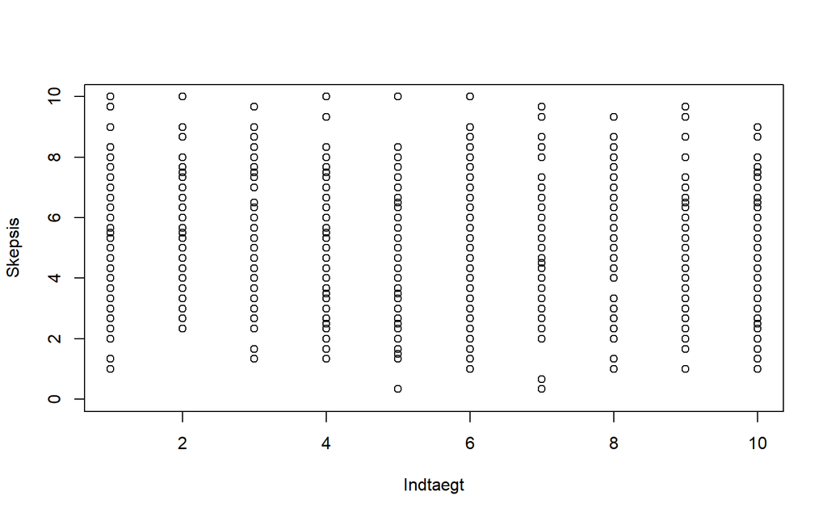

```r
df %>%
  select(Indtaegt, Skepsis) %>%
  plot
```

#### ggplot2

I can do the same thing in ggplot and take the advantage of its additional functions to make the plot more legible.

I want to draw points, so I add the elements in the `geom_point()` function to the blank sheet.

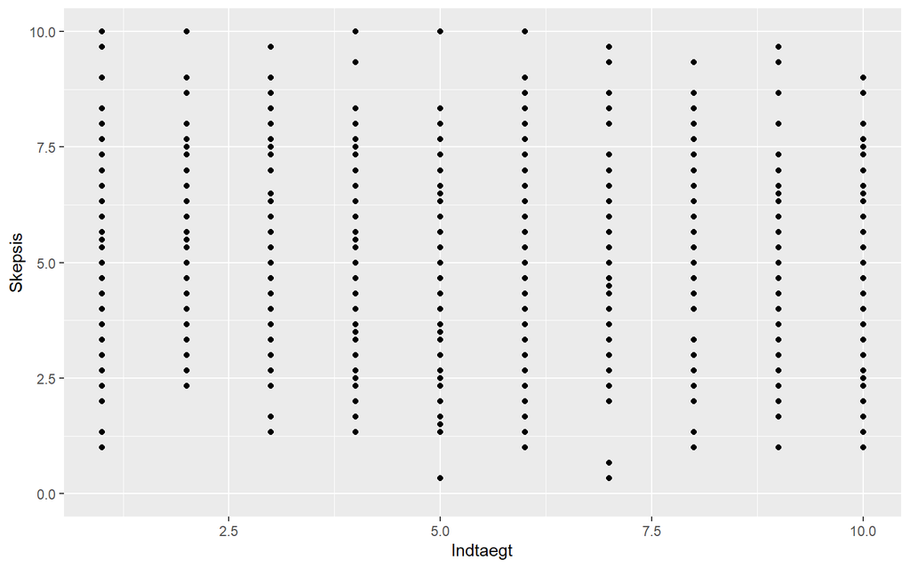

A simple scatter plot gives an impression of the bivariate relationship between immigration skepticism and income.

```r
df %>%
  ggplot +
  geom_point(aes(y = Skepsis,
                 x = Indtaegt))
```

It is hard to see any relationship between the two variables. Also, they only shared some 2% of their variation. However, the income variable also consists only of integers. Therefore, the points overlap each other, and we get a poor idea of how many units exist within the different value combinations. We can’t see what value combinations are the most common, only that there are a lot of them.

We can solve this in two ways: by making the points partially transparent, or by moving them slightly apart.

**Transparent color** I can specify that I want transparent colors. I do this with the argument `alpha=`. The value I specify ranges from 0 (completely transparent/invisible) to 1 (not transparent).

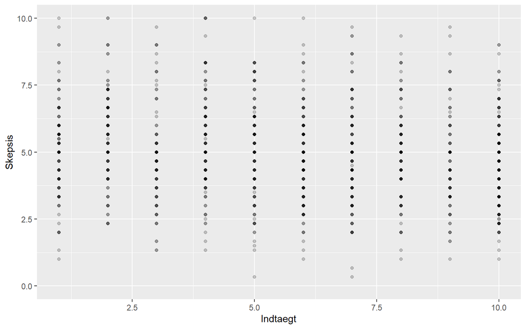

By using a transparent color, I can show where the majority of the observations are located in the distribution.

```r
df %>%
  ggplot +
  geom_point(aes(y = Skepsis,
                 x = Indtaegt),
             #all observations are transparent
             alpha = 0.2)
```

Note that when we want to adjust the points without the adjustment being dependent on information from the data, this is done outside of aes() but within the geom_…() function.

**Jitter data** Another alternative is to “jitter” the data points a little. This means that R adds a random variation to the coordinates of the points. The actual data points become more imprecise, but the point here is not to perform a precise analysis, but to present relationships in the data so that the human eye gets an intuitive understanding of what is going on.

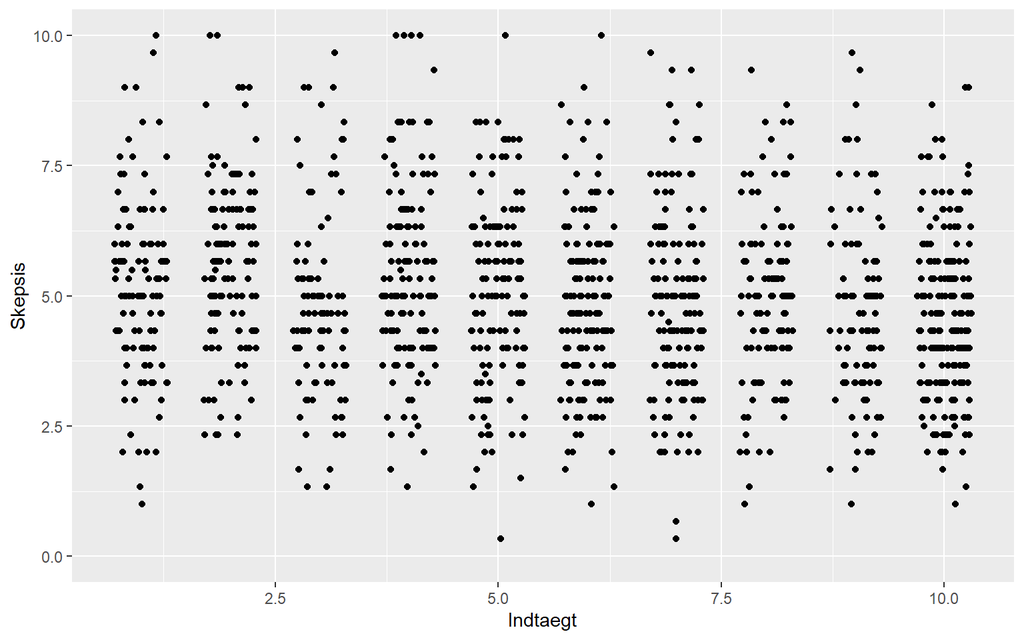

I get a better grasp of where my observations are by ‘shaking’ the data points.

```r
df %>%
  ggplot +
  geom_jitter(aes(y = Skepsis,
                  x = Indtaegt),
              #Horizontal, but not vertical shake
              height = 0, width = 0.3)
```

The additional arguments `width=` and `height=` specify how much the points should be jittered horizontally and vertically, respectively. Here, I say that I want precise data along the y-axis (“in height”), but I let the points randomly vary by 0.3 units along the x-axis (“in width”).

### Trivariate graphics: Group the data.

I can easily add more groupings. Here I am coloring the points based on the value of a third variable: The variable can be continuous or categorical.

**Numeric/continous grouping** “Prekaritet” flags respondents that have a weak link to the labor market (i.e. they are unemployed or on a temporary work contract).

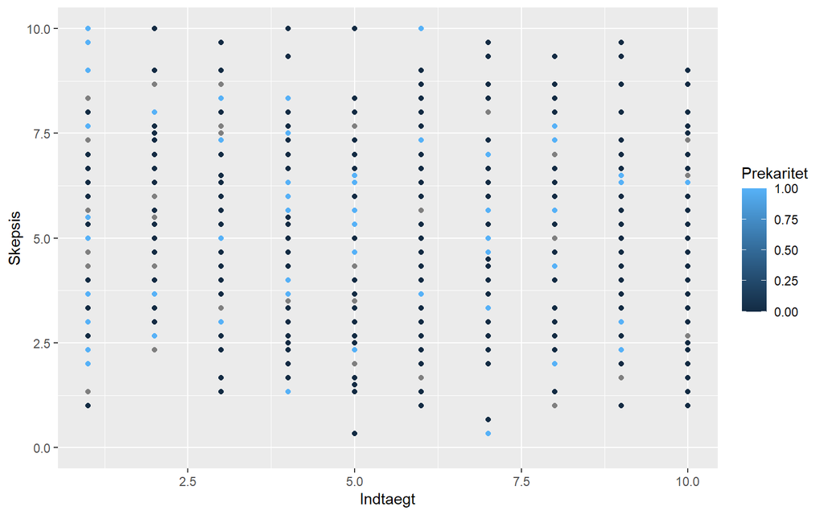

```r
df %>%
  ggplot +
  geom_point(aes(y = Skepsis,
                 x = Indtaegt,
                 #Grouping
                 color = Prekaritet))
```

Now I get a “heat scale” for the respondent’s link to the labor market. ggplot also automatically provides a legend. Now, the variable only has two values, 0 or 1. We better use it as a categorical moderator.

**Categorical grouping** If I want a categorical grouping, I need to feed the function a categorical variable (“character” or “factor”). It’s best to do this by mutating the data frame using tidyverse, not in the ggplot() function. Right here, I use `as.factor()` to change the measurement level into categorical.

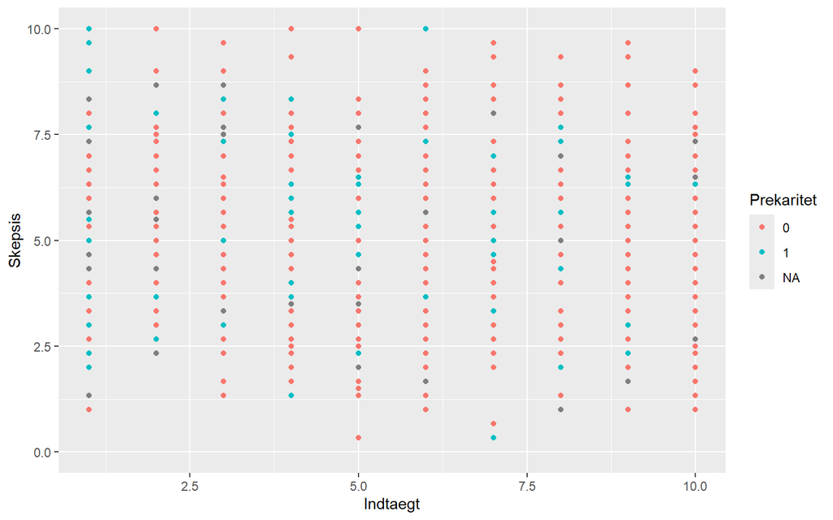

```r
df %>%
  mutate(Prekaritet = as.factor(Prekaritet)) %>%
  ggplot +
  geom_point(aes(y = Skepsis,
                 x = Indtaegt,
                 #Grouping
                 color = Prekaritet))
```

Of course, I can combine all these solutions – jittering, transparency and recoding – until I get a plot that tells the story I want to convey.

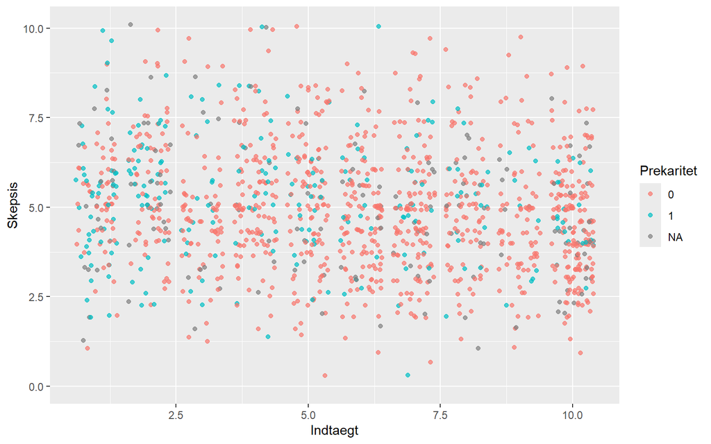

```r
#tidyverse to transform the data
df %>%
  mutate(Prekaritet = as.factor(Prekaritet)) %>%
  #ggplot2 to plot the data
  ggplot +
  geom_jitter(aes(y = Skepsis,
                 x = Indtaegt,
                 #Continuous moderating third variable
                 color = Prekaritet),
              #Shake data data horizontaly and vertically
              height = 0.1, width = 0.4,
              #Transparency
              alpha = 0.7)
```

It is hard to tell much from this graphic, so let’s move on to other visualizations.

### Bivariate regression lines

I can also show the relationship between two variables using regression lines. ggplot does not report regression coefficients but instead illustrates the regression line and the uncertainty around it. This is particularly relevant if at least one of the variables (the x-variable) is continuous.

Now we can choose between local regression and ordinary linear regression. Which one we choose depends on what we want to achieve.

#### Local regression

Local regression is – in my eyes – the queen of all ggplot functions. I use it all the time when exploring my data. It draws a “smooth” line (locally, the sliding average over the different x-values). Perfectly suited for time trends or exploring non-linear relationships, for example.

The function that gives us bivariate regression lines is `geom_smooth()`. The default setting is local regression.

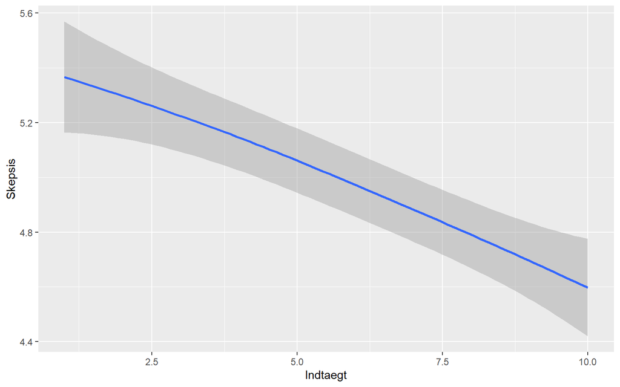

Local regression: A simple way to present empirical relationships between two variables.

```r
df %>%
ggplot +
  geom_smooth(aes(y = Skepsis,
                  x = Indtaegt))
```

**Grouped:** Is the relationship the same within different categories?

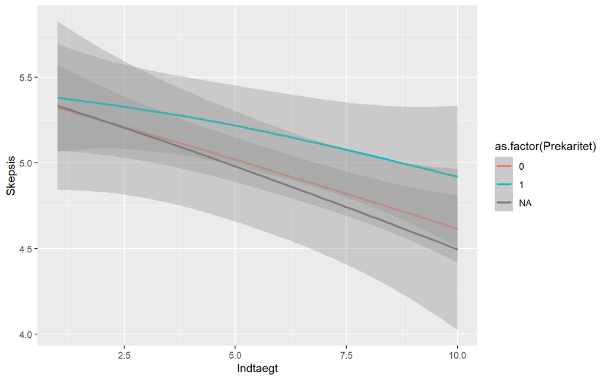

Local regression: The queen of trivariate plots?

```r
df %>%
  ggplot +
  geom_smooth(aes(y = Skepsis,
                  x = Indtaegt,
                  color = as.factor(Prekaritet)))
```

Would you like to replace the “spaghetti” with straight lines? Ask for a (bivariate) linear model.

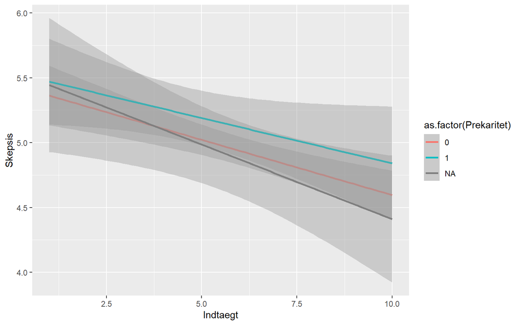

```r
df %>%
  ggplot +
  geom_smooth(aes(y = Skepsis,
                  x = Indtaegt,
                  color = as.factor(Prekaritet)),
              method = "lm")
```

## Your turn!

- Plot the relationship between income (x = `Indtaegt`) and weak link to the labor market (y = `Prekaritet`) using a local regression. What do you find? Would it make sense to swap the two, i.e. let income be on the y-axis?
- Use the tidyverse `mutate()` function to create a new variable that flags whether a respondent has answered the question about labor market connection. Redefine the new variable into a numeric using the `as.numeric()` function. Then plot the relationship between income (`Indtaegt`) and the new variable using a local regression. What do you find?

## One numeric and one cagetorical variable (+ more tidyverse)

When we have a numeric and a categorical variable we’d like to explore, we will usually calculate the group mean; i.e. we calculate the average of the numeric variable for each of the categories in the other.

### Numeric summary: group averages

This is a good excuse to have a second look at `tidyverse` . `dplyr` has a very handy function that allows us to do operations on subset of the data depending on a moderating variable.

Let’s calculate the average scepticism among voters of different parties and create a summary statistic. To do so, we use `reframe()`

```r
df %>%
  group_by(Parti) %>%
  reframe("Scepticism" = mean(Skepsis, na.rm = T))
```

| Parti | Scepticism |
| --- | --- |
| Andet | 5.343137 |
| Dansk Folkeparti | 6.290210 |
| Det Konservative Folkeparti | 4.846154 |
| Det Radikale Venstre | 4.067164 |
| Enhedslisten | 4.646930 |
| Kristendemokraterne | 4.333333 |
| Liberal Alliance | 4.934028 |
| Socialdemokraterne | 4.756266 |
| Socialistisk Folkeparti | 4.507716 |
| Venstre | 5.055376 |

[output cut: 1 more lines]

Before moving on, I’m removing the NAs.

```r
df %>%
  filter(!is.na(Parti)) %>%
  group_by(Parti) %>%
  reframe("Scepticism" = mean(Skepsis, na.rm = T))
```

| Parti | Scepticism |
| --- | --- |
| Andet | 5.343137 |
| Dansk Folkeparti | 6.290210 |
| Det Konservative Folkeparti | 4.846154 |
| Det Radikale Venstre | 4.067164 |
| Enhedslisten | 4.646930 |
| Kristendemokraterne | 4.333333 |
| Liberal Alliance | 4.934028 |
| Socialdemokraterne | 4.756266 |
| Socialistisk Folkeparti | 4.507716 |
| Venstre | 5.055376 |

The observations are ordered alphabetically. It is not intuitive. Let’s rearrange.

```r
df %>%
  filter(!is.na(Parti)) %>%
  group_by(Parti) %>%
  reframe("Scepticism" = mean(Skepsis, na.rm = T)) %>%
  arrange(Scepticism)
```

| Parti | Scepticism |
| --- | --- |
| Det Radikale Venstre | 4.067164 |
| Kristendemokraterne | 4.333333 |
| Socialistisk Folkeparti | 4.507716 |
| Enhedslisten | 4.646930 |
| Socialdemokraterne | 4.756266 |
| Det Konservative Folkeparti | 4.846154 |
| Liberal Alliance | 4.934028 |
| Venstre | 5.055376 |
| Andet | 5.343137 |
| Dansk Folkeparti | 6.290210 |

No surprises here; Dansk Folkeparti has voters that are more sceptical than other parties. This being said, in general, there is not a massive spread here.

My results looked ok, so I’m storing them in `tab`.

```r
tab <-
  df %>%
  filter(!is.na(Parti)) %>%
  group_by(Parti) %>%
  reframe("Scepticism" = mean(Skepsis, na.rm = T)) %>%
  arrange(Scepticism)
```

### Visual: barplot

Let’s instead plot this.

#### base

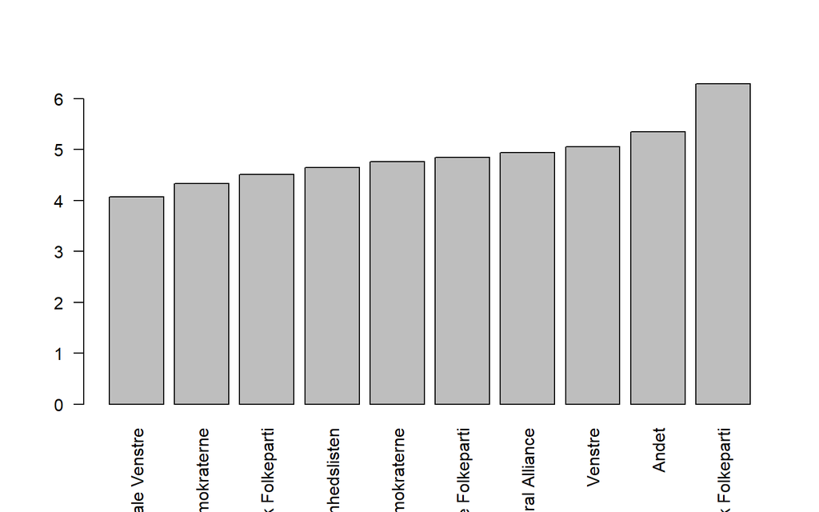

```r
barplot(tab$Scepticism,
        names.arg = tab$Parti,
        las = 2)
```

#### ggplot2

Instead of plotting the entire data set, I now rely on my table also in ggplot2. That is, I’ve already calculated the height of the bars, so no need for ggplot to do that. I signal my intent by using the `geom_col()` function. It simply reads the coordinates from the data frame so that the y-values and the x-values are defined by me.

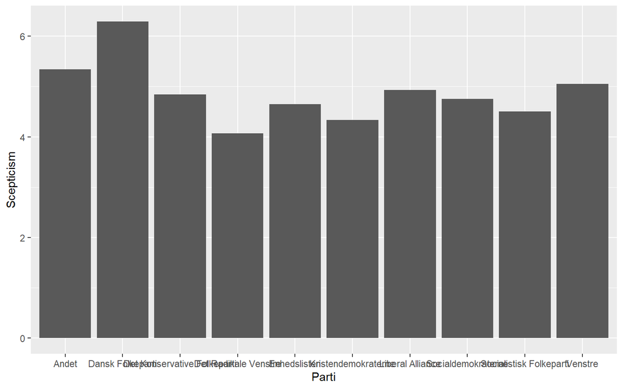

```r
tab %>%
  ggplot +
  geom_col(aes(y = Scepticism,
               x = Parti))
```

**Bonus**

Would you like to order your columns by size? You can do that by reordering the x-varible (`Parti`) according to the values of scepticism; i.e. you define it as an ordered categorical variable. The function is `reorder()`.

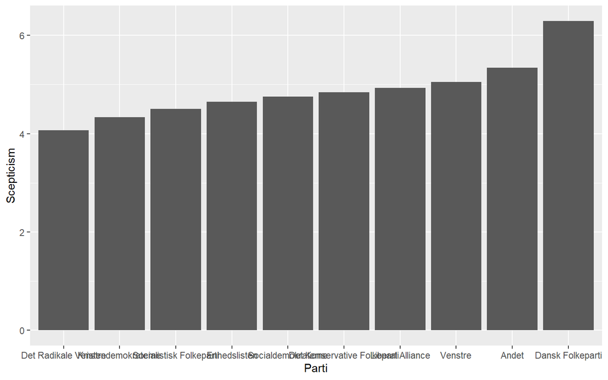

```r
tab %>%
  mutate(Parti = reorder(Parti, Scepticism)) %>%
  ggplot +
  geom_col(aes(y = Scepticism,
               x = Parti))
```

## Two categorical variables

When we have two categorical variables, we do a cross-table.

```r
table(df$Parti, df$Kvinde)
```

```
##
##                                 0   1
##   Andet                        11   6
##   Dansk Folkeparti             85  58
##   Det Konservative Folkeparti  33  32
##   Det Radikale Venstre         69  65
##   Enhedslisten                 32  45
##   Kristendemokraterne           4   4
##   Liberal Alliance             38  10
##   Socialdemokraterne          116 152
##   Socialistisk Folkeparti      43  65
##   Venstre                     175 136
```

Absolute frequencies are hard to fathom. I like them relative. Also, this time around, we want to know the proportion of voters that are men/women per party. It means that I calculate the distribution by rows (margin = 1).

```r
table(df$Parti, df$Kvinde) %>%
  prop.table(., margin = 1)
```

```
##
##                                       0         1
##   Andet                       0.6470588 0.3529412
##   Dansk Folkeparti            0.5944056 0.4055944
##   Det Konservative Folkeparti 0.5076923 0.4923077
##   Det Radikale Venstre        0.5149254 0.4850746
##   Enhedslisten                0.4155844 0.5844156
##   Kristendemokraterne         0.5000000 0.5000000
##   Liberal Alliance            0.7916667 0.2083333
##   Socialdemokraterne          0.4328358 0.5671642
##   Socialistisk Folkeparti     0.3981481 0.6018519
##   Venstre                     0.5627010 0.4372990
```

We don’t usually test the statistical significance, when we explore the data. However, we can. The chisquare test allows us to check if the data table is generated by random. The p-value reports the probability that the relationships we see are generated by accident. Here, that’s very unlikely.

```r
table(df$Parti, df$Kvinde) %>%
  chisq.test()
```

```
##
##  Pearson's Chi-squared test
##
## data:  .
## X-squared = 38.546, df = 9, p-value = 1.391e-05
```

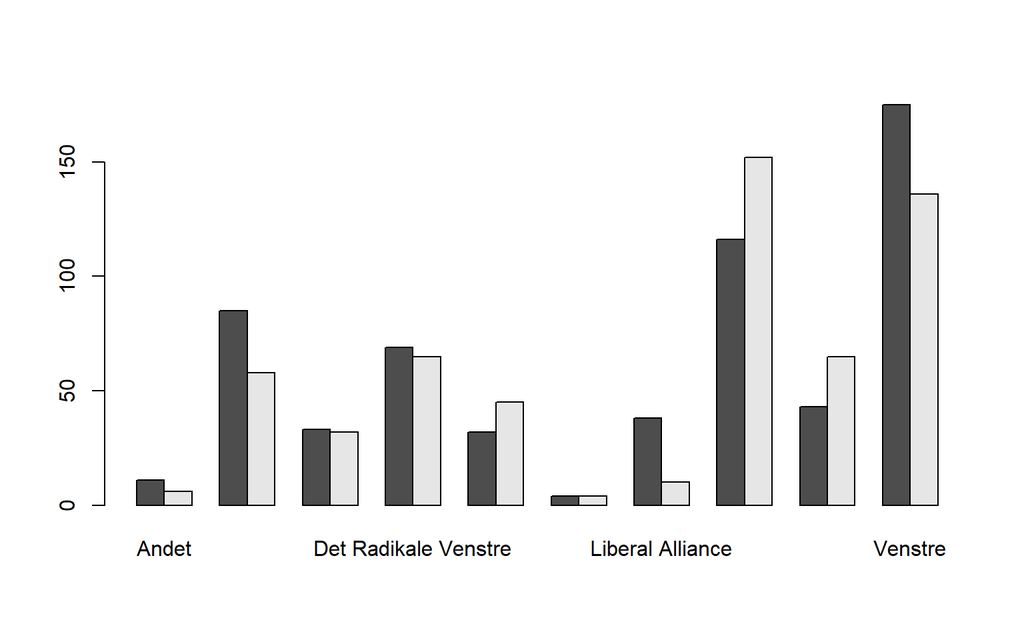

```r
table <- table(df$Kvinde, df$Parti)

barplot(table,
        beside = T)
```

#### ggplot2

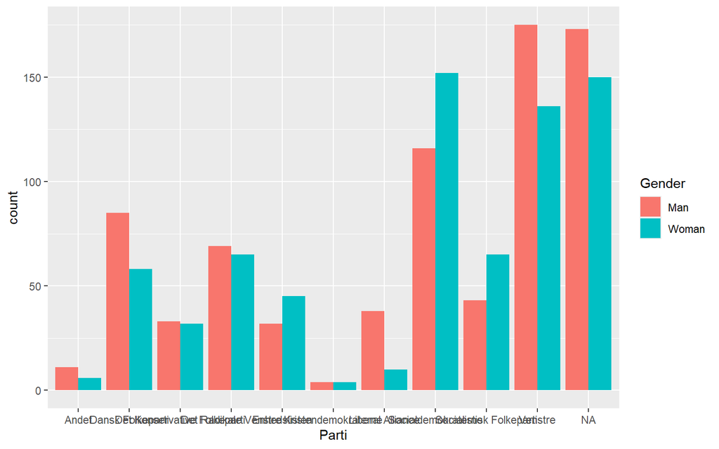

```r
df %>%
  #Create a new variable with categorical names
  mutate(Gender = if_else(Kvinde == 1,
                         "Woman",
                         "Man")) %>%
  #Plot
  ggplot +
  geom_bar(aes(x = Parti,
               #Moderate by gender
               fill = Gender),
           position = "dodge")
```

# Key take-aways

- explore the data and use graphics
- choose statistics according to measurement level
- use `tidyverse`/`dplyr` to reshape the data for group averages etc.
- use `ggplot2` to plot the data

**Key functions in `tidyverse/dplyr` (numeric manipulation)**

| Function | What it does |
| --- | --- |
| `filter()` | Filters out observations |
| `select()` | Selects variables |
| `group_by()` | Groups the data |
| `mutate()` | Adds/changes variables, but not the number of observations |
| `reframe()` | Reduces to a data frame with fewer/summarizing variables |

**Key functions in `ggplot` (graphical display)**

| Function | What it does | Reshapes the data? | Measurement level | Statistic |
| --- | --- | --- | --- | --- |
| `ggplot()` | Creates a blank page |  |  |  |
| `geom_bar()` | barplot/frequency count. | Yes. | One or two categorical variables | Univariate, Bi-/trivariate |
| `geom_histogram()` | histogram. | Yes | Numeric | Univariate |
| `geom_point()` | points/scatterplot. | No. Uses variables as coordinates. | Two numerical variables | Bivariate |
| `geom_col()` | bars/barplot | No. Uses data as coordinates, so `dplyr::mutate()` might be needed. | One categorical and one numeric variable; height is group mean | Bivariate |
| `geom_smooth()` | local regression line. | Yes | Two numeric or one binary (y) and one numeric | Bivariate |

### Recap exercise

Our end-of-class class activity was to find some potential variables, define their measurement level, the statistics we can do to describe them and the visuals that might be useful.

**Overview of potential descriptive statistics:**

| N. of variables | variable name | measurement level | statistic | graphic | geom_… |
| --- | --- | --- | --- | --- | --- |
| *Univariate* |  |  |  |  |  |
|  | `income` | continous, bounded at 0 | mean, quartiles, median, sd | histogram | `geom_histogram()` |
|  | `party choice` | categorical | frequency table | barplot | `geom_bar()` |
|  | `job satisfaction` | ordinal, treated as either numeric or categorical |  |  |  |
|  | `air strikes` | count; bounded at 0 | mean, etc. | histogram | `geom_histogram()` |
| *Bivariate* |  |  |  |  |  |
|  | `party choice + gender` | categorical + categorical (or treated as continous) | cross table | barplot | `geom_bar()` |
|  | `income + grades` | continuous + ordinal (treated as categorical) | group means; avg. income foree ach grade | barplot | `geom_col()` |
|  | `negotiation time + preference agreement` | continuous + continous | Pearson’s R | scatterplot; local regression | `geom_point()` `geom_smooth()` |

# Workflow and tweaks in ggplot2

Let’s follow an alternative workflow and create our own small dataset for plotting. Here, I am interested in immigration skepticism among respondents with different work situations.

```r
dfp <-
  df %>%
  #Filter out NA
  filter(!is.na(Prekaritet) & !is.na(Innvandrer)) %>%
  #Group
  group_by(Prekaritet, Innvandrer) %>%
  #Create a smaller data frame with group summary statistics
  reframe(
    #Group average of immigration attitudes
    Sceptical = mean(Skepsis, na.rm = T)) %>%
  #Define new variable names to appear for the viewer
  mutate(
    #New variable with intutitive answers; note the "quotation marks"
    `How is your work situation?` = if_else(Prekaritet == 1,
                                            "Unstable",
                                            "Stable"),
    Immigrant = if_else(Innvandrer == 1,
                     "Immigrant", "Non-immigrant"))

dfp
```

| Prekaritet | Innvandrer | Sceptical | How is your work situation? | Immigrant |
| --- | --- | --- | --- | --- |
| 0 | 0 | 4.992282 | Stable | Non-immigrant |
| 0 | 1 | 4.492138 | Stable | Immigrant |
| 1 | 0 | 5.305108 | Unstable | Non-immigrant |
| 1 | 1 | 4.905983 | Unstable | Immigrant |

```r
p <-
  dfp %>%
  ggplot +
  #Classical definition of x and y coordinates
  geom_col(aes(y = Sceptical,
               x = Immigrant,
               #Fill in with colors following the grouping
               fill = `How is your work situation?`),
           #place bars side-by-side
           position = "dodge")
```

Note how I have saved my plot in an object: `p <- ggplot()`. To see the plot, I request it.

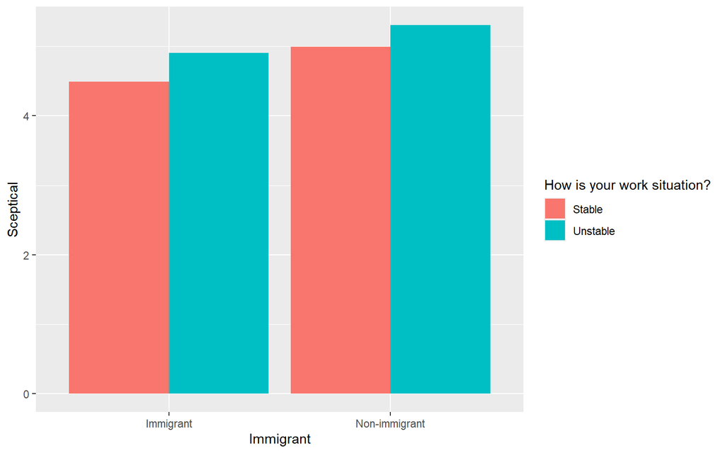

A bar chart created from a separate dataset where I have aggregated and prepared the information.

```r
p
```

It is useful to save the object this way because I will modify my R object further. I can do that using pipes.

### Esthetical tweaks

Once you have added the graphical elements with your data, you can spend an endless amount of time fine-tuning the rest of the plot.

### Tell R what language you speak (and where you are)

R was not created by Norwegians, so Danish characters can sometimes cause problems. We have to actively consider encoding choices in two settings: when we import data and when we save data, including in graphics.

```r
Sys.setlocale(category = "LC_ALL",
              locale = "dk_DK.UTF-8")
```

## Titles and axis names

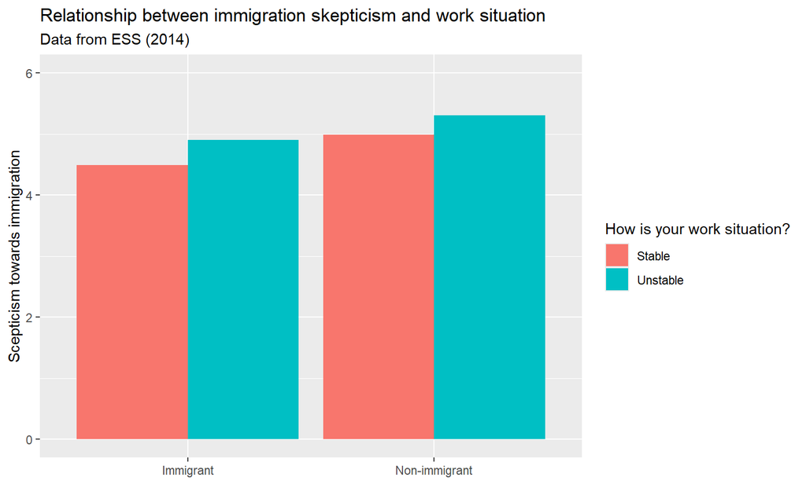

```r
p <-
  p +
  #Add a title and a subtitle
  ggtitle(label = "Relationship between immigration skepticism and work situation",
          subtitle = "Data from ESS (2014)") +
  #Name of y-axis
  ylab("Scepticism towards immigration") +
  #Name of x-axis: empty
  xlab("") +
  #What are the limits on my axis?
  ylim(c(0,6))

p
```

### Define colors

You can choose your own colors, and there are many ways to do so. If you have linked your data with color choices, it may be useful to define a “palette.”

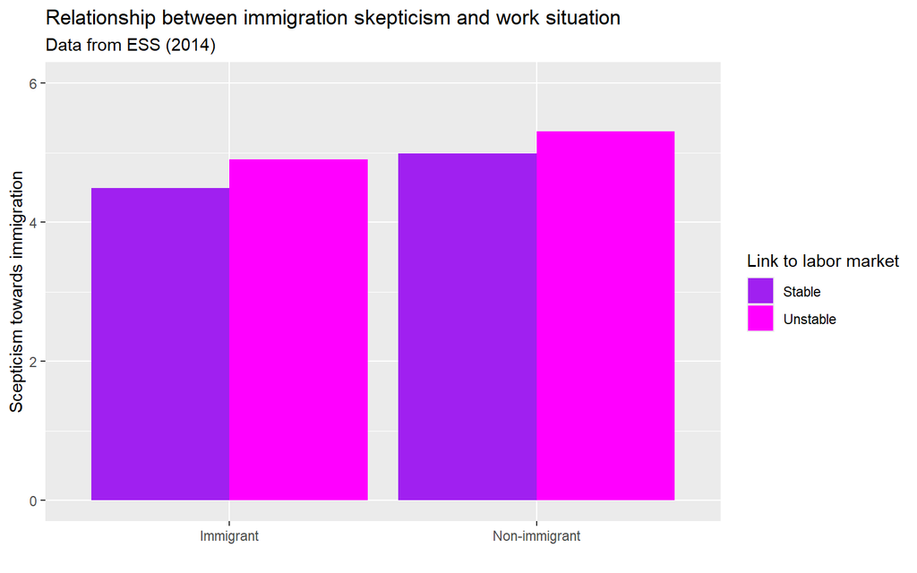

```r
p <-
  p +
  #Define colors
  scale_color_manual(
    #What colors?
    values = c("purple", "magenta"),
    #Color the entire bar
    aesthetics = "fill",
    #What's the title of the legend?
    name = "Link to labor market",
    #What are the category names?
    labels = c("Stable",
               "Unstable")
    )
p
```

### Background

You can define different templates for the aesthetic aspects of the plot with `theme_...()`.

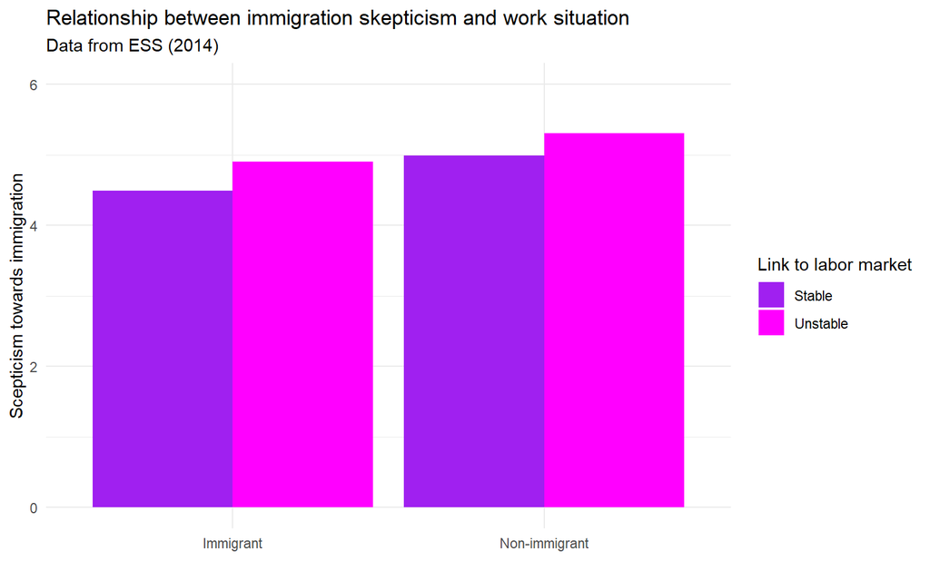

Here, I am using ready-made functions to modify the visual expression of the plot.

```r
p <-
  p +
  # Define a theme
  theme_minimal()
p
```

You can alter the themes at will. You do that after you have defined the theme, using the generik `theme()` function.

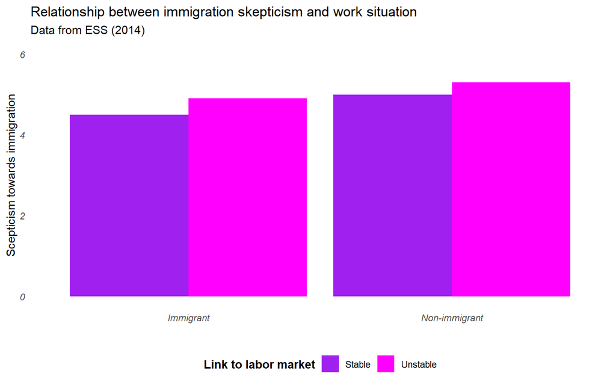

Here, I’ve changed the background and other thematical elements in my graphic.

```r
p <-
  p +
  # Modify the minimal theme after defining it
  theme(
    # Move the legend down to below the plot
    legend.position = "bottom",
    # Bold font for the title in the legend
    legend.title = element_text(face = "bold"),
    # Italic for axis values
    axis.text = element_text(face = "italic"),
    # Remove the gridlines
    panel.grid = element_blank())
p
```

The `element_...()` functions are used inside the `theme()` function. They specify everything except the data content/information for an element. Should it be a blank element element_blank()? Specific font? `element_text()`… etc.